# Support Vector Machines

[figure not shown]

## Support Vector Machines **Instructor: Mehdi Rezvandehy**

Introduction

Support Vector Machine (SVM) is a powerful algorithm to perform linear or nonlinear classification, regression or outlier detection. It is highly preferred since less computation power is required to produce reliable accuracy. SVM is one of the tools that should be applied for any Machine Learning project.

# SVM Linear Classification

The Figure below shows the fundamental idea for SVM. We have two classes, circle (Class 1) and star (Class 2) based on two features (Feature 1 and Feature 2). The classes are linearly separable. Left Figure shows decision boundaries of three possible linear classifier: the decision boundaries of blue and red lines seems ok but decision boundary of dashed green line is very bad that cannot properly separate two classes. Although blue and red lines works perfectly for training set, they may be inefficient to predict a new instance. On the contrary, the decision boundary of solid black line in right Figure is achieved by SVM classifier; this line not only divides perfectly the two classes but also stays as far away from the closest training instances as possible. **A SVM classifier works like fitting the widest possible street (parallel dashed lines) between the classes. This approach is called large margin classification.**

[figure not shown]

If you have more training instances that are “off the street”, the decision boundary will not be affected at all: the instances located on the edge of the street determine the decision boundaries. These instances shown in large circles are called the support vectors.

It must be noted that SVM are sensitive to the feature scales. It is highly recommended to standardize your features before applying SVM.

We just applied hard margin classification; however, in practice, it may not always works because 1- the data should be linearly separable that may not be the case all the time 2- SVM is very sensitive to outliers. To avoid this, we should have a more flexible SVM model that allows a few instances on the street and wrong sides. In fact, we should have a balance of large street and reduced margin violation. This technique is called soft margin classification.

We can control this balance using the C hyperparameter in Scikit-Learn’s SVM classes: by decreasing C value, we will have wider street but margin violations will also increase.

Figure below shows two classes (circle and star) that are non-linear. The decision boundaries and margins of for two soft margin SVM classifiers are shown in the Figure using different C hyperparameters. On the left Figure, C is low C=1, that means the margin is quite large, but we have many street violations. On the right Figure, by using a high C value, smaller margin is achieved leading to fewer margin violations. However, the left model is more likely better generalized since most margin violations are in correct side of the decision boundary. You can apply C as a regularization to reduce overfitting: reducing C leads to reduce overfitting and increasing C may lead to overfitting.

[figure not shown]

Lets apply a linear SVM model using Scikit-Learn for binary classification of Energy Efficiency Data Set used in previous lectures.

```python
import pandas as pd
import numpy as np

df = pd.read_csv("Building_Heating_Load.csv") # Energy Efficiency Data Set
df[0:5]
```

|  | Relative Compactness | Surface Area | Wall Area | Roof Area | Overall Height | Orientation | Glazing Area | Glazing Area Distribution | Heating Load | Binary Classes | Multi-Classes |
| --- | --- | --- | --- | --- | --- | --- | --- | --- | --- | --- | --- |
| 0 | 0.98 | 514.5 | 294.0 | 110.25 | 7.0 | 2 | 0.0 | 0 | 15.55 | Low Level | Level 2 |
| 1 | 0.98 | 514.5 | 294.0 | 110.25 | 7.0 | 3 | 0.0 | 0 | 15.55 | Low Level | Level 2 |
| 2 | 0.98 | 514.5 | 294.0 | 110.25 | 7.0 | 4 | 0.0 | 0 | 15.55 | Low Level | Level 2 |
| 3 | 0.98 | 514.5 | 294.0 | 110.25 | 7.0 | 5 | 0.0 | 0 | 15.55 | Low Level | Level 2 |
| 4 | 0.90 | 563.5 | 318.5 | 122.50 | 7.0 | 2 | 0.0 | 0 | 20.84 | Low Level | Level 2 |

```python
df_binary=df.copy()
df_binary.drop(['Heating Load','Multi-Classes'], axis=1, inplace=True)
```

```python
# Convert Class to Numbers
df_binary['Binary Classes']=df_binary['Binary Classes'].replace('Low Level', 0)
df_binary['Binary Classes']=df_binary['Binary Classes'].replace('High Level', 1)
df_binary[0:5]
```

|  | Relative Compactness | Surface Area | Wall Area | Roof Area | Overall Height | Orientation | Glazing Area | Glazing Area Distribution | Binary Classes |
| --- | --- | --- | --- | --- | --- | --- | --- | --- | --- |
| 0 | 0.98 | 514.5 | 294.0 | 110.25 | 7.0 | 2 | 0.0 | 0 | 0 |
| 1 | 0.98 | 514.5 | 294.0 | 110.25 | 7.0 | 3 | 0.0 | 0 | 0 |
| 2 | 0.98 | 514.5 | 294.0 | 110.25 | 7.0 | 4 | 0.0 | 0 | 0 |
| 3 | 0.98 | 514.5 | 294.0 | 110.25 | 7.0 | 5 | 0.0 | 0 | 0 |
| 4 | 0.90 | 563.5 | 318.5 | 122.50 | 7.0 | 2 | 0.0 | 0 | 0 |

```python
np.random.seed(32)
df_binary=df_binary.reindex(np.random.permutation(df_binary.index))
df_binary.reset_index(inplace=True, drop=True)
```

```python
from sklearn.model_selection import StratifiedShuffleSplit

# Training and Test
spt = StratifiedShuffleSplit(n_splits=1, test_size=0.2, random_state=42)
for train_idx, test_idx in spt.split(df_binary, df_binary['Binary Classes']):
    train_set_strat = df_binary.loc[train_idx]
    test_set_strat  = df_binary.loc[test_idx]
```

```python
# Note that drop() creates a copy and does not affect train_set_strat
X_train = train_set_strat.drop("Binary Classes", axis=1)
y_train = train_set_strat["Binary Classes"].values
```

```python
from sklearn.preprocessing import StandardScaler

# Standardize features
scaler = StandardScaler()
X_train=X_train.copy()
X_train_Std=scaler.fit_transform(X_train)
```

For a Linear SVC, we can either use Scikit-Learn with a linear SVM model using the LinearSVC or use the SVC class, using SVC(kernel="linear", C=1), but SVC is very slower for large training sets. SVC is more efficient for small data set that are non linearly separable. Lets try LinearSVC first:

```python
from sklearn.svm import LinearSVC

# SVM Classifier model
np.random.seed(32)
svm_clf = LinearSVC(C=1)
svm_clf.fit(X_train_Std, y_train)
```

```
LinearSVC(C=1)
```

```python
#svm_clf.intercept_
```

```python
svm_clf.predict(X_train_Std[0:10])
```

```
array([0, 1, 1, 0, 0, 1, 0, 1, 0, 0], dtype=int64)
```

```python
y_train[0:10]
```

```
array([0, 1, 1, 0, 0, 0, 0, 1, 0, 0], dtype=int64)
```

```python
from sklearn.model_selection import cross_val_score

Accuracies=cross_val_score(svm_clf,X_train_Std,y_train, cv=4, scoring="accuracy")
Accuracies
```

```
array([0.92207792, 0.84415584, 0.90849673, 0.88888889])
```

```python
from sklearn.model_selection import cross_val_predict

y_train_pred = cross_val_predict(svm_clf,X_train_Std,y_train, cv=4)
```

```python
from sklearn.metrics import confusion_matrix

def Conf_Matrix(predictor,x_train,y_train,perfect,sdt,axt=None):
    '''Plot confusion matrix'''
    ax1 = axt or plt.axes()
    y_train_pred = cross_val_predict(predictor,x_train,y_train, cv=4)
    if(perfect==1): y_train_pred=y_train
    conf_mx=confusion_matrix(y_train, y_train_pred)
    ii=0
    if(len(conf_mx)<4):
        im =ax1.matshow(conf_mx, cmap='jet', interpolation='nearest')
        x=['Predicted\nNegative', 'Predicted\nPositive']; y=['Actual\nNegative', 'Actual\nPositive']
        for (i, j), z in np.ndenumerate(conf_mx):
            if(ii==0): al='TN= '
            if(ii==1): al='FP= '
            if(ii==2): al='FN= '
            if(ii==3): al='TP= '
            ax1.text(j, i, al+'{:0.0f}'.format(z), ha='center', va='center', fontweight='bold',fontsize=8.5)
            ii=ii+1
        ax1.set_xticks(np.arange(len(x)))
        ax1.set_xticklabels(x,fontsize=6.5,y=0.97, rotation='horizontal')
        ax1.set_yticks(np.arange(len(y)))
        ax1.set_yticklabels(y,fontsize=6.5,x=0.035, rotation='horizontal')
    else:
        if(sdt==1):
            row_sums = conf_mx.sum(axis=1, keepdims=True)
            norm_confmx = conf_mx / row_sums
        else:
            norm_confmx=conf_mx

        im =ax1.matshow(norm_confmx, cmap='jet', interpolation='nearest')
        for (i, j), z in np.ndenumerate(norm_confmx):
            if(sdt==1): ax1.text(j, i, '{:0.2f}'.format(z), ha='center', va='center', fontweight='bold')
            else: ax1.text(j, i, '{:0.0f}'.format(z), ha='center', va='center', fontweight='bold')
    cbar =plt.colorbar(im,shrink=0.3,orientation='vertical')
```

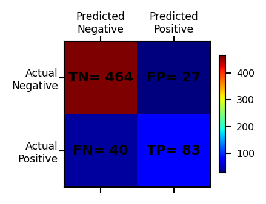

```python
import matplotlib
import pylab as plt

font = {'size'   : 6}
matplotlib.rc('font', **font)
fig = plt.subplots(figsize=(4.5, 4.5), dpi= 190, facecolor='w', edgecolor='k')

ax1=plt.subplot(1,2,1)
Conf_Matrix(svm_clf,X_train_Std,y_train,perfect=0,sdt=0,axt=ax1)
```

```python
from sklearn.metrics import precision_score, recall_score

precision=precision_score(y_train, y_train_pred)
print('Precision= ',precision)

recall=recall_score(y_train, y_train_pred)
print('Recall (sensitivity)= ',recall)
```

```
Precision=  0.7545454545454545
Recall (sensitivity)=  0.6747967479674797
```

# SVM Non-linear Classification

We applied linear SVM but some data may not be linearly separable. We saw in previous lectures that by adding new feature such as polynomial degree, nonlinear data can be converted to linear and then linear modeling can be applied. We can do the same for SVM. Lets apply a Linear SVM using polynomial features for a synthetic dataset.

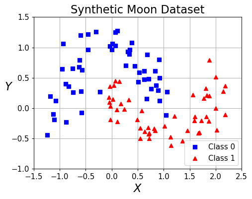

```python
font = {'size'   : 12}
matplotlib.rc('font', **font)
fig = plt.subplots(figsize=(6.0, 4.5), dpi= 90, facecolor='w', edgecolor='k')

from sklearn.datasets import make_moons

x1, y1 = make_moons(n_samples=100, noise=0.2, random_state=22)

def moon_dataset(x1, y1, axes):
    plt.plot(x1[:, 0][y1==0], x1[:, 1][y1==0], "bs",label='Class 0')
    plt.plot(x1[:, 0][y1==1], x1[:, 1][y1==1], "r^",label='Class 1')
    plt.xlabel(r"$X$", fontsize=18)
    plt.ylabel(r"$Y$", fontsize=18, rotation=0)
    plt.grid(True, which='both')
    plt.legend(loc=4)
    plt.axis(axes)

moon_dataset(x1, y1, [-1.5, 2.5, -1, 1.5])
plt.title('Synthetic Moon Dataset', fontsize=18)

plt.show()
```

```python
from sklearn.pipeline import Pipeline
from sklearn.preprocessing import PolynomialFeatures

polynomial_svm_clf = Pipeline([
        ("poly_features", PolynomialFeatures(degree=3)),
        ("scaler", StandardScaler()),
        ("svm_clf", LinearSVC(C=4, loss="hinge", random_state=70))
    ])

polynomial_svm_clf.fit(x1, y1)
```

```
Pipeline(steps=[('poly_features', PolynomialFeatures(degree=3)),
                ('scaler', StandardScaler()),
                ('svm_clf', LinearSVC(C=4, loss='hinge', random_state=70))])
```

### Hinge Loss

Hinge loss is primarily used with SVM. It not only penalizes the wrong predictions but also not confident about right predictions. The function for the hinge loss is max(0, 1 – t); for t ≥ 1, it is equal to 0. If t < 1, the derivative of lost Hinge loss is equal to –1; otherwise, if t > 1, the derivative is 0. So, the Gradient Descent can be used to calculate optimum weights. The code below shows Hinge loss

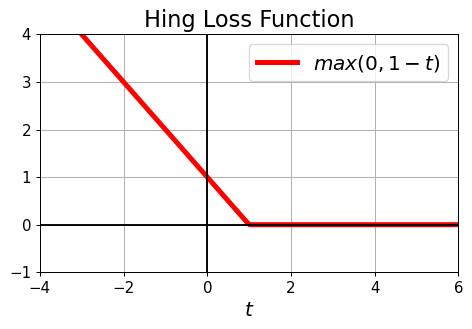

```python
font = {'size'   : 12}
matplotlib.rc('font', **font)
fig = plt.subplots(figsize=(6.0, 3.5), dpi= 90, facecolor='w', edgecolor='k')

t = np.linspace(-5, 8, 200)
hing = np.where(1 - t < 0, 0, 1 - t)  # max(0, 1-t)

plt.plot(t, hing, "r-", linewidth=4, label="$max(0, 1 - t)$")
plt.grid(True, which='both')
plt.axhline(y=0, color='k'); plt.axvline(x=0, color='k')
plt.xlabel("$t$", fontsize=16)
plt.title("Hing Loss Function", fontsize=18)
plt.axis([-4, 6, -1, 4])
plt.legend(loc=1, fontsize=16)
plt.show()
```

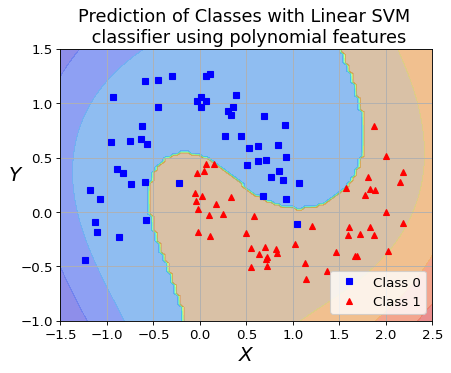

```python
font = {'size'   : 12}
matplotlib.rc('font', **font)
fig = plt.subplots(figsize=(6.0, 4.5), dpi= 80, facecolor='w', edgecolor='k')

def predictions(clf, ax):
    x_0 = np.linspace(ax[0], ax[1], 100)
    x_1 = np.linspace(ax[2], ax[3], 100)
    x0, x1 = np.meshgrid(x_0, x_1)
    X = np.c_[x0.ravel(), x1.ravel()]
    y_pred = clf.predict(X).reshape(x0.shape)
    y_decision = clf.decision_function(X).reshape(x0.shape)
    plt.contourf(x0, x1, y_pred, cmap='jet', alpha=0.3)
    plt.contourf(x0, x1, y_decision, cmap='jet', alpha=0.2)

predictions(polynomial_svm_clf, [-1.5, 2.5, -1, 1.5])
moon_dataset(x1, y1, [-1.5, 2.5, -1, 1.5])
plt.title('Prediction of Classes with Linear SVM \n classifier using polynomial features', fontsize=16)

plt.show()
```